# Question 1

## a) No

The least squares method (or minimal least squares) is specifically designed to find the minimum value for this estimator. In the case of least squares, the cost function or loss function being optimised is the sum of squared differences between the predicted and actual values. As a result the minimum MSE is equal to the minimal least squares.

## b) Model Error

The mean squared estimator measures the average squared difference between the predicted values and the actual values. This is the model or reducible error that the model has not been able to fit. The irreducible error on the other is not captured by the MSE. It arises from factors that are beyond the model's control, such as inherent noise in the data, unpredictable events, or unknown variables that influence the target variable.

# Question 2

Entropy quantifies the disorder or randomness of the class labels within a subset of data.

## a) False

Entropy measures the impurity or disorder within a dataset. High entropy indicates that the partition is impure with a more mixed distribution of data points within that partition. This implies there is no clear separation of the data and that there is no majority class.

## b) True

High entropy means that there is a high level of impurity in the classes. The data cannot be easily defined or separated and the characteristics of each partition are mixed. In the context of decision trees, high entropy means that we cannot, with a high probability, assign new data points to a partition with high entropy.

# Question 3 - Feature Engineering

Perform subset selection using any or all of a) Filter, b) wrapper and, c) embedded methods

## Run Packages

```python
# Data Manipulation
import numpy as np
import pandas as pd
import matplotlib.pyplot as plt
import yfinance as yf

# Visualizaiton
import seaborn as sns
plt.style.use('seaborn')

# Data Preprocessing
from sklearn.model_selection import (
                            train_test_split,
                            GridSearchCV,
                            TimeSeriesSplit,
                            cross_val_score,
RandomizedSearchCV)

from sklearn.preprocessing import StandardScaler, MinMaxScaler, RobustScaler

from sklearn.pipeline import Pipeline

from sklearn import svm

from scipy.stats import norm, kurtosis

import statsmodels.api as sm

from sklearn.neighbors import KNeighborsClassifier

#from xgboost import XGBClassifier, plot_importance, to_graphviz

from sklearn.svm import SVR

from sklearn.metrics import (accuracy_score,
                             f1_score,
                             recall_score,
                             precision_score,
                             roc_auc_score,
                             auc,
                             classification_report,
                             confusion_matrix,
                             precision_recall_curve,
                             roc_curve,
                             RocCurveDisplay,
                             ConfusionMatrixDisplay,
                             classification_report,
                             confusion_matrix,
                             r2_score,
                             mean_squared_error,
                             mean_absolute_error                            )

# Regressor
from sklearn.linear_model import Lasso, Ridge, ElasticNet, LinearRegression

#
import shap

import pyfolio as pf

# set display options
pd.options.display.float_format = "{:,.4f}".format

# Machine info & package version
from watermark import watermark
%load_ext watermark
%watermark -a "Louis Treneman" -u -d -v -m -iv

# Ignore warnings
import warnings
warnings.filterwarnings('ignore')
```

```
The watermark extension is already loaded. To reload it, use:
  %reload_ext watermark
Author: Louis Treneman

Last updated: 2023-06-15

Python implementation: CPython
Python version       : 3.10.9
IPython version      : 8.10.0

Compiler    : MSC v.1916 64 bit (AMD64)
OS          : Windows
Release     : 10
Machine     : AMD64
Processor   : AMD64 Family 23 Model 24 Stepping 1, AuthenticAMD
CPU cores   : 4
Architecture: 64bit

pandas     : 1.5.3
seaborn    : 0.12.2
statsmodels: 0.13.5
pyfolio    : 0.9.2
numpy      : 1.23.5
yfinance   : 0.2.18
matplotlib : 3.7.0
shap       : 0.41.0
sklearn    : 1.2.2
```

## Hypothesis

Choice of ticker

- I have chosen the Gold Futures ticker which is traded on COMEX.
- This will trade at a small premium to the actual price of gold but will be an accurate proxy to all the underlying properties of the commodity that I am looking for.
- This is because of the cost-of-carry pricing model, the futures price should be the same as the current spot price plus the cost of carrying (or storing) the underlying asset until the maturity of the futures contract. If the spot and futures prices are out of alignment, arbitrage activity would occur and rectify the imbalance.
- Futures positions are marked to market daily, and, as the underlying instrument's price moves, this will be reflected in the future price.

My overall hypothesis is that Gold should display some good properties to implement a successful trading strategy on it.

## Data Loading

```python
# load introductory data
df = yf.download("GC=F", start="2013-05-24",end="2023-05-27", interval="1d") # Selecting intraday data as my signal for up / down moves
df.columns = df.columns.str.upper()
df.describe()
```

```
[*********************100%***********************]  1 of 1 completed
```

|  | OPEN | HIGH | LOW | CLOSE | ADJ CLOSE | VOLUME |
| --- | --- | --- | --- | --- | --- | --- |
| count | 2,519.0000 | 2,519.0000 | 2,519.0000 | 2,519.0000 | 2,519.0000 | 2,519.0000 |
| mean | 1,452.7973 | 1,459.9030 | 1,445.6710 | 1,452.7897 | 1,452.7897 | 5,382.3636 |
| std | 272.7311 | 274.5527 | 271.1256 | 272.8688 | 272.8688 | 29,436.8961 |
| min | 1,053.7000 | 1,062.0000 | 1,046.2000 | 1,050.8000 | 1,050.8000 | 0.0000 |
| 25% | 1,242.1000 | 1,248.3500 | 1,237.2000 | 1,243.5000 | 1,243.5000 | 44.0000 |
| 50% | 1,318.1000 | 1,322.8000 | 1,312.7000 | 1,317.7000 | 1,317.7000 | 167.0000 |
| 75% | 1,747.4500 | 1,754.3500 | 1,738.0500 | 1,747.7500 | 1,747.7500 | 526.5000 |
| max | 2,053.6001 | 2,072.0000 | 2,040.0000 | 2,051.5000 | 2,051.5000 | 386,334.0000 |

```python
df['matching'] = df.apply(lambda x: x.CLOSE == x['ADJ CLOSE'], axis=1)
df['matching']

print(df.loc[df['matching'] == False])
```

```
Empty DataFrame
Columns: [OPEN, HIGH, LOW, CLOSE, ADJ CLOSE, VOLUME, matching]
Index: []
```

This represents 10 years worth of trading data. As a result, I should have enough data to proceed.

I will also proceed with Adjusted close as it is the same as CLOSE price data. Shown in the above.

```python
# check for missing values
df.isnull().sum()
```

```
OPEN         0
HIGH         0
LOW          0
CLOSE        0
ADJ CLOSE    0
VOLUME       0
matching     0
dtype: int64
```

Thankfully my initial data is clean as it comes from yfinance. I have a full set of data points across my required range. I do not have to fill any of the data forwards or backwards.

## Introductory Data Analysis

Quick view of the data that I am going to be dealing with. Understand any general trend that may be occurring.

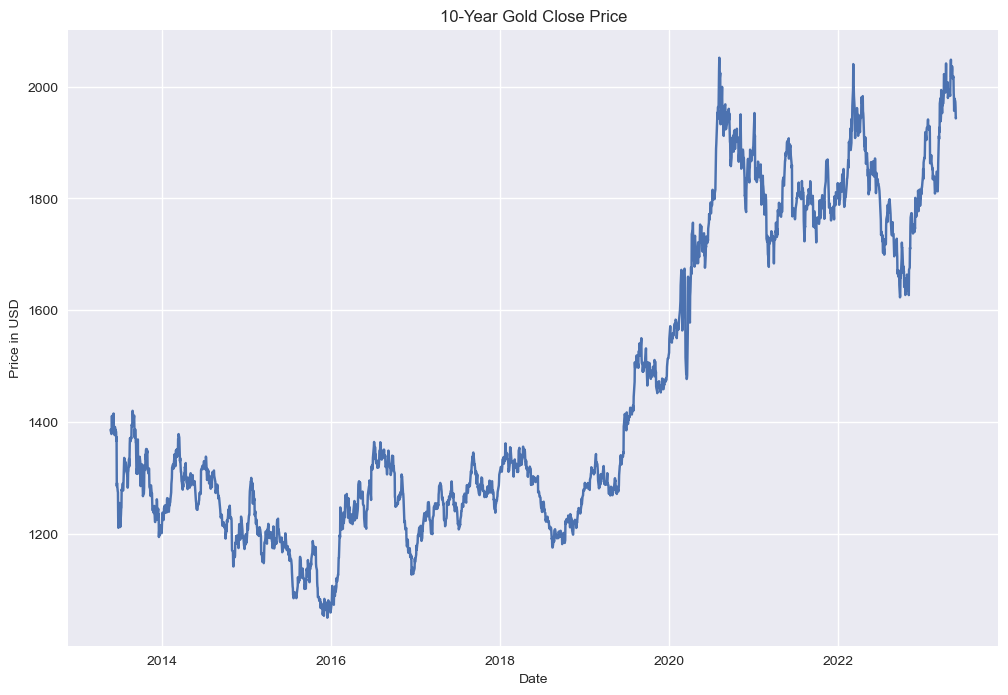

```python
# Initial Data anlysis
plt.figure(figsize=(12,8))
plt.plot(df['ADJ CLOSE'])
plt.xlabel("Date"), plt.ylabel("Price in USD")
plt.title("10-Year Gold Close Price")
```

Over 10 years, we have seen a flattish period followed by more recent significant up trends which centred around the global pandemic and more recently global price inflation increasing.

## Feature Engineering/ Creation

Features are also known as an independent variable which are used to determine the value of the target variable. We will create features and target (label) from the raw dataset.

```python
# create features
def create_features(frame):
    df = frame.copy()

    # Gold Price features
    df['OC'] = df['ADJ CLOSE'] / df['OPEN'] - 1
    df['HL'] = df['HIGH'] / df['LOW'] - 1
    df['LRET'] = np.log(df['ADJ CLOSE'] / df['ADJ CLOSE'].shift(1))
    df['RET'] = (df['ADJ CLOSE'] - df['ADJ CLOSE'].shift(1))/df['ADJ CLOSE'].shift(1)
    df['MOM'] = df['ADJ CLOSE']- df['ADJ CLOSE'].shift(1)
    df['PRET'] = np.log(df['ADJ CLOSE'].shift(1)/ df['ADJ CLOSE'].shift(2))

    for i in [7]:
        df['LRET' + str(i)] = df['LRET'].rolling(i).sum()
        df['RET' + str(i)] = (df['ADJ CLOSE'] - df['ADJ CLOSE'].shift(i))/df['ADJ CLOSE'].shift(i)
        df['MA' + str(i)] = df['ADJ CLOSE'].rolling(i).mean()
        df['EWMA_' + str(i)] = df['ADJ CLOSE'].ewm(span = 7, adjust = False).mean()
        df['OC'+ str(i)] = df['OC'].rolling(i).mean()
        df['HL'+ str(i)] = df['HL'].rolling(i).mean()
        df['MOM'+ str(i)] = df['ADJ CLOSE']- df['ADJ CLOSE'].shift(i)
        df['PRET'+str(i)] = np.log(df['ADJ CLOSE'].shift(1)/ df['ADJ CLOSE'].shift(i+2))

    df['LABEL'] = df['ADJ CLOSE'].shift(-1)
    # drop NaN values
    df.dropna(inplace=True)
    return df

# Create Data Frame
df = create_features(df)

# Create X Data Frame
X = df.drop(['ADJ CLOSE','OPEN', 'HIGH', 'LOW', 'CLOSE', 'VOLUME', 'LABEL','matching'], axis=1)

# LABEL
Y = np.array(df['LABEL'])
```

```python
X.head()
```

| Date | OC | HL | LRET | RET | MOM | PRET | LRET7 | RET7 | MA7 | EWMA_7 | OC7 | HL7 | MOM7 | PRET7 |
| --- | --- | --- | --- | --- | --- | --- | --- | --- | --- | --- | --- | --- | --- | --- |
| 2013-06-07 | -0.0202 | 0.0277 | -0.0234 | -0.0231 | -32.7000 | 0.0123 | -0.0060 | -0.0060 | 1,401.4286 | 1,397.3565 | -0.0005 | 0.0209 | -8.3000 | 0.0206 |
| 2013-06-10 | 0.0054 | 0.0082 | 0.0023 | 0.0023 | 3.2000 | -0.0234 | -0.0181 | -0.0179 | 1,397.8143 | 1,394.5674 | -0.0017 | 0.0190 | -25.3000 | 0.0028 |
| 2013-06-11 | -0.0052 | 0.0135 | -0.0067 | -0.0066 | -9.2000 | 0.0023 | -0.0113 | -0.0112 | 1,395.5857 | 1,390.1755 | -0.0004 | 0.0171 | -15.6000 | -0.0037 |
| 2013-06-12 | 0.0122 | 0.0144 | 0.0107 | 0.0107 | 14.8000 | -0.0067 | -0.0142 | -0.0141 | 1,392.7429 | 1,390.5817 | -0.0010 | 0.0163 | -19.8999 | -0.0247 |
| 2013-06-13 | -0.0066 | 0.0127 | -0.0103 | -0.0102 | -14.2001 | 0.0107 | -0.0141 | -0.0140 | 1,389.9571 | 1,387.3362 | -0.0005 | 0.0156 | -19.5000 | -0.0006 |

- Because I have have created derivatives of the original price features (High, Low, Open, Close, Adjusted close), I can drop them as they will not add much more additional value.
- Although Volume will contribute to the demand of Gold and therefore price, I am not going to include it in my model.
- My dependent variable is the T+1 adjusted close price. This is the signal I am going to try and predict in my machine learning model. I have labeled this as my LABEL.

In the above, I have created a number of features around different price mechanisms and signals.

1. Intraday Price Range.

1. Log Returns.

$$ LRET = \ln (\frac{P_t}{P_{t-i}}) \hspace{3cm} [3] $$

where $ P_t $ is Adjusted Close price.

1. Past Returns

$$ RET = \frac{P_t - P_{t-i}}{P_{t-i}} \hspace{3cm} [4] $$

1. Gap between trading days.

1. Simple moving average

$$ MA = \frac{1}{n} \sum_{i=0}^{n=1} P_{t-i} \hspace{3cm} [6]$$

1. Exponentially weighted moving average

$$ EWMA = EWMA_{t-1} + \mathcal{a}[P_t - EWMA_{t-1}] \hspace{3cm} [7]$$

1. Momentum

$$ MOM = P_t - P_{t-i} \hspace{3cm} [8] $$

1. Past Returns

$$ PRET = \frac{P_{t-1} - P_{t-i+1}}{P_{t-i+1}} \hspace{3cm} [9] $$

## Exploratory Data Analysis

```python
X.describe()
```

|  | OC | HL | LRET | RET | MOM | PRET | LRET7 | RET7 | MA7 | EWMA_7 | OC7 | HL7 | MOM7 | PRET7 |
| --- | --- | --- | --- | --- | --- | --- | --- | --- | --- | --- | --- | --- | --- | --- |
| count | 2,509.0000 | 2,509.0000 | 2,509.0000 | 2,509.0000 | 2,509.0000 | 2,509.0000 | 2,509.0000 | 2,509.0000 | 2,509.0000 | 2,509.0000 | 2,509.0000 | 2,509.0000 | 2,509.0000 | 2,509.0000 |
| mean | 0.0000 | 0.0098 | 0.0001 | 0.0002 | 0.2102 | 0.0001 | 0.0009 | 0.0012 | 1,452.1237 | 1,452.1121 | 0.0000 | 0.0098 | 1.5746 | 0.0011 |
| std | 0.0084 | 0.0079 | 0.0097 | 0.0097 | 14.6383 | 0.0097 | 0.0247 | 0.0247 | 272.2260 | 272.0194 | 0.0031 | 0.0049 | 36.9124 | 0.0262 |
| min | -0.0530 | 0.0000 | -0.0660 | -0.0638 | -97.1001 | -0.0660 | -0.1253 | -0.1178 | 1,063.7857 | 1,063.5635 | -0.0213 | 0.0000 | -197.2000 | -0.1323 |
| 25% | -0.0037 | 0.0046 | -0.0045 | -0.0044 | -6.2999 | -0.0045 | -0.0141 | -0.0140 | 1,242.5000 | 1,242.5942 | -0.0017 | 0.0067 | -20.0000 | -0.0149 |
| 50% | 0.0000 | 0.0082 | 0.0002 | 0.0002 | 0.2999 | 0.0002 | 0.0011 | 0.0011 | 1,317.7429 | 1,316.8345 | 0.0001 | 0.0091 | 1.5000 | 0.0017 |
| 75% | 0.0040 | 0.0130 | 0.0051 | 0.0051 | 7.5000 | 0.0051 | 0.0161 | 0.0162 | 1,749.3429 | 1,748.2353 | 0.0019 | 0.0121 | 23.0000 | 0.0172 |
| max | 0.0529 | 0.0813 | 0.0578 | 0.0595 | 93.2000 | 0.0578 | 0.1016 | 0.1070 | 2,028.8143 | 2,024.6879 | 0.0136 | 0.0445 | 166.6001 | 0.1072 |

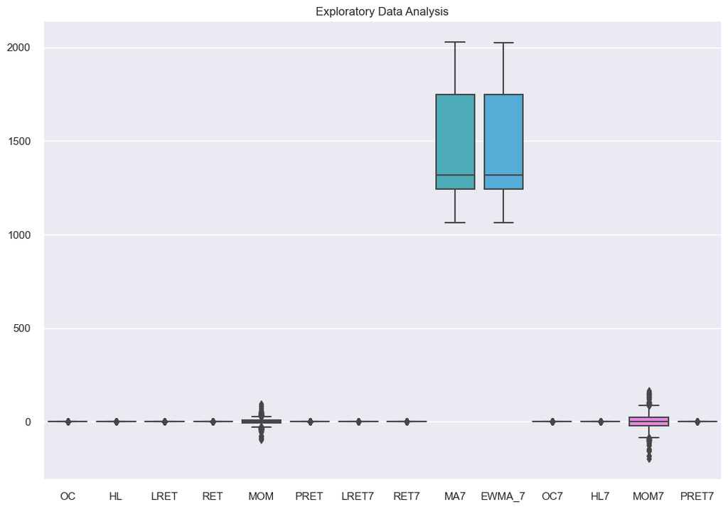

```python
sns.set(rc={'figure.figsize':(12.5,8.5)})
sns.boxplot(x='variable', y ='value', data =pd.melt(X))
plt.xlabel(''); plt.ylabel('')
plt.title('Exploratory Data Analysis')
```

### Normalising Data

```python
# fit scaler on training data
norm = MinMaxScaler().fit(X)

# transform training data
data_norm = pd.DataFrame(norm.transform(X), index = X.index, columns = X.columns)
```

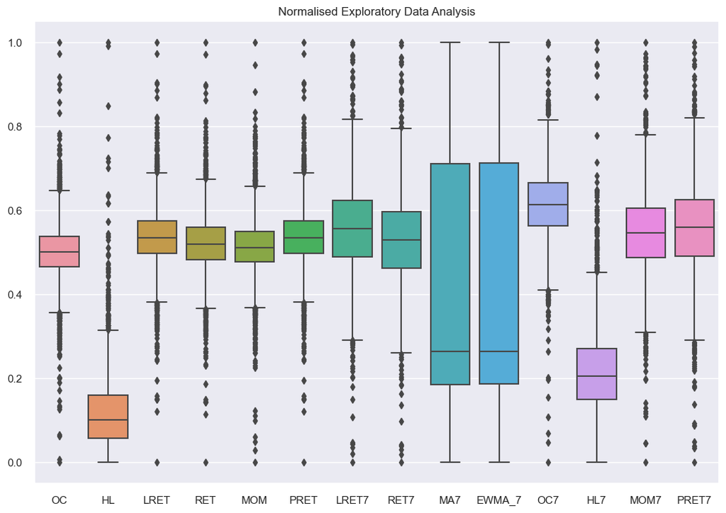

```python
sns.boxplot(x='variable', y ='value', data =pd.melt(data_norm))
plt.xlabel(''); plt.ylabel('')
plt.title('Normalised Exploratory Data Analysis')
```

### Standardising Data

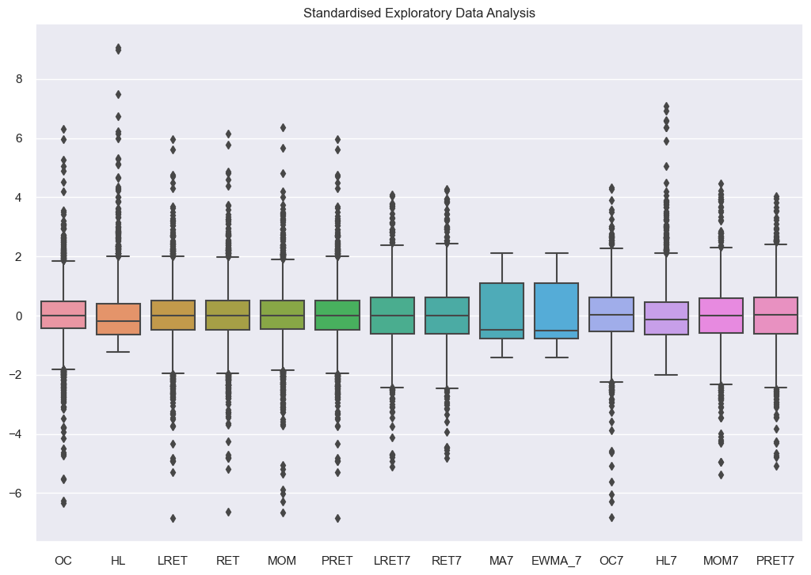

```python
pipe = Pipeline([
    ('scaler', StandardScaler()),
    ('regressor', LinearRegression())
])

# fit scaler on training data
stand = StandardScaler().fit(X)

# transform training data
data_stnd = pd.DataFrame(stand.transform(X), index = X.index, columns = X.columns)

#plotting Data
sns.boxplot(x='variable', y ='value', data =pd.melt(data_stnd))
plt.xlabel(''); plt.ylabel('')
plt.title('Standardised Exploratory Data Analysis')
```

## Feature Selection

### Correlation Heat map

Here I will use a heat map to show which features have multicollinearity. The value at which I will drop these features will be discussed below.

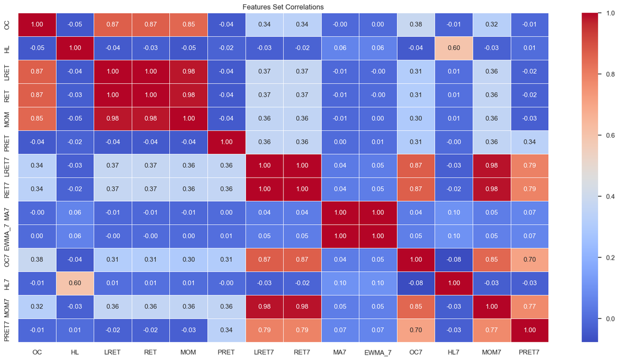

```python
sns.set(rc={'figure.figsize': (20, 10)})
sns.heatmap(X.corr(),
            annot=True,
            annot_kws={"size": 11},
            fmt=".2f",
            linewidth=.5,
            cmap="coolwarm",
            cbar=True); #cmap="crest", virids, magma

plt.title('Features Set Correlations');
```

```python
# drop the highly correlated features
to_drop = ['OC','RET','MOM','RET7','MA7','LRET7','OC7','PRET7']
X.drop(to_drop, axis=1, inplace=True)

# record feature names
feature_names = X.columns
```

- Dropping features that have a correlation greater than 0.75
- We want to drop it from our model. This will help us reduce the dimensionality by dropping a feature but will also save us from other statistical problems such as multi-collinearity, where corr > 0.75. This is part of the sub-set selection methods, filter method based on the ranking of correlations

Choice between features:

- Here I prefer Log Returns (LRET) over normal Returns returns due to several of the kind mathematical properties of log returns. In particular, it is better for additivity and deals with extreme values which is all part of the pre-processing methodology.

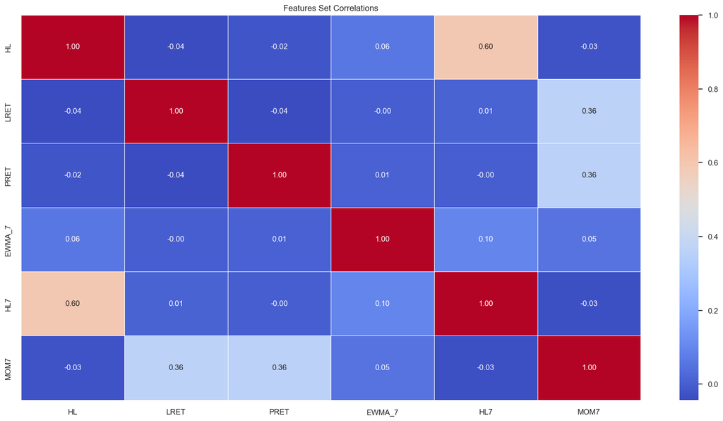

```python
sns.set(rc={'figure.figsize': (20, 10)})
sns.heatmap(X.corr(),
            annot=True,
            annot_kws={"size": 11},
            fmt=".2f",
            linewidth=.5,
            cmap="coolwarm",
            cbar=True); #cmap="crest", virids, magma

plt.title('Features Set Correlations');
```

- The secondary heat map here shows we have removed all features that that display multicollinearity greater than 0.75.
- I will move onto some embedded methods for feature selection.

## Embedded Methods for feature Selection

- Lasso and Ridge are both regularising methods, they aim to regularise complex models by introducing penalty factors. They are great at reducing overfitting, handling multicollinearity, or just automatic feature engineering.

```python
class Regression:
    def __init__(self, X, Y, testsize=0.20): ### TEST Size, 20%, this is user defined

        self.X = X
        self.Y = Y
        self.testsize = testsize

        # split training and testing dataset
        self.X_train, self.X_test, self.y_train, self.y_test = train_test_split(self.X,
                                                                                self.Y,
                                                                                test_size=self.testsize,
                                                                                random_state=0,
                                                                                shuffle=False)

    # fit and predict
    def fit_predict(self, estimator, transformer, alpha=None, l1_ratio=None):

        try:
            # subsume estimators and transformer into a pipeline
            model = Pipeline([
            ('scaler', transformer),
            ('regressor', estimator)
            ])

            # fit/train model
            model.fit(self.X_train, self.y_train)

            # predict lables
            y_pred = model.predict(self.X_test)

        except Exception as e:
            print(str(e))

        return model, model['regressor'].intercept_, model['regressor'].coef_, y_pred

    # evaluate metrics
    def eval_metrics(self,model, y_pred):

        # evaluate metrics
        mse = mean_squared_error(self.y_test, y_pred, squared=True)
        rmse = mean_squared_error(self.y_test, y_pred, squared=False)
        r2train = model.score(self.X_train, self.y_train)
        r2test = model.score(self.X_test, self.y_test)

        return mse, rmse, r2train, r2test

    # plot coefficients as a function of lambda
    def plot_coeff(self, modelname):

        coef = []
        model = Regression(self.X, self.Y, 0.20)
        alpha_range = np.logspace(2, -2, 200)

        if modelname == 'Lasso':
            for i in alpha_range:
                coef.append(model.fit_predict(Lasso(alpha=i, random_state=0), MinMaxScaler())[2])

        elif modelname == 'Ridge':
            alpha_range = np.logspace(6, -2, 200)
            for i in alpha_range:
                coef.append(model.fit_predict(Ridge(alpha=i, random_state=0), MinMaxScaler())[2])

        elif modelname == 'ElasticNet':
            for i in alpha_range:
                coef.append(model.fit_predict(ElasticNet(alpha=i, random_state=0), MinMaxScaler())[2])

        # Plot Coefficients
        fig = plt.figure(figsize=(20,8))
        ax = plt.axes()

        ax.plot(alpha_range, coef)
        ax.set_xscale('log')
        ax.legend(feature_names, loc=0)
        # ax.set_xlim(ax.get_xlim()[::-1])  # reverse axis
        ax.set_title(f'{modelname} coefficients as a function of the regularization')
        ax.set_xlabel('$\lambda$')
        ax.set_ylabel('$\mathbf{w}$')

        return plt.show()
```

### Lasso Regression - L1 Cost Function

- The Least Absolute Shrinkage and Selection Operator (LASSO) is a variation of linear regression. In Lasso, the loss function is minimized by limiting the sum of absolute values of the model coefficients where the L1 penalty term is added to the Mean Square Error (MSE). The L1 penalty term not only shrinks the coefficents, but shrinks some of them to zero and that is very useful for feature selection.

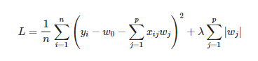

where, λ is the regularization penalty that is added to the RSS. The λ here is a hyperparameter that can be tuned.

```python
# instantiate
lasso = Regression(X,Y)

# fit Lasso
lasso_model , lasso_intercept, lasso_coef, lasso_y_pred = lasso.fit_predict(Lasso(alpha=0.3, random_state=0), MinMaxScaler())
lasso_model , lasso_intercept, lasso_coef, X.columns
```

```
(Pipeline(steps=[('scaler', MinMaxScaler()),
                 ('regressor', Lasso(alpha=0.3, random_state=0))]),
 997.1924963274992,
 array([  0.        ,  35.49592873,  11.51214737, 936.28388058,
          0.        ,  79.532723  ]),
 Index(['HL', 'LRET', 'PRET', 'EWMA_7', 'HL7', 'MOM7'], dtype='object'))
```

- Here we can see a number of coefficients from LASSO have been labelled as 0. This is due to the L1 penalty term. This suggests that these features have no impact in deciding the signal that we are attempting to model.
- I will therefore remove the subset of features shown below.

```python
Xnew = X.drop(['HL','HL7'],axis=1)
```

Graphing LASSO below, we can see the shrinkage of coefficients.

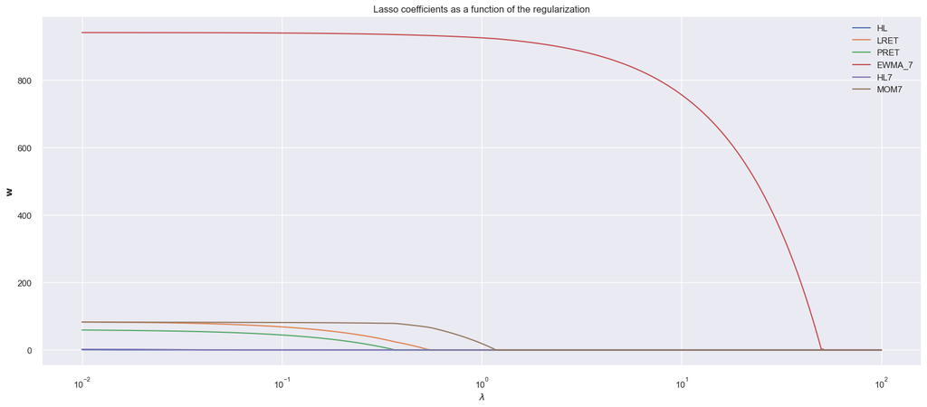

```python
# plot coefficients
lasso.plot_coeff('Lasso')
```

### Ridge Regression - L2 Cost function

In ridge regression, the cost function is altered by adding a L2 penalty which is equivalent to squaring the magnitude of the coefficients. The Ridge regression shrinks the coefficients and helps to reduce the multi-collinearity. When λ → 0, the cost function becomes similar to the linear regression cost function.

When λ → $ \infty $ this shrinks the coefficients of the dependent variables. This is another hyperparameter to tune.

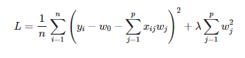

#### Ridge where Lambda = 1

```python
# instantiate
ridge = Regression(X,Y)

# fit Ridge
ridge_model , ridge_intercept, ridge_coef, ridge_y_pred = ridge.fit_predict(Ridge(alpha=1, random_state=0), MinMaxScaler())
ridge_model , ridge_intercept, ridge_coef, X.columns
```

```
(Pipeline(steps=[('scaler', MinMaxScaler()),
                 ('regressor', Ridge(alpha=1, random_state=0))]),
 948.1616635463581,
 array([  1.22181072,  78.1254139 ,  56.10728209, 932.08801521,
          5.70225388,  83.77873626]),
 Index(['HL', 'LRET', 'PRET', 'EWMA_7', 'HL7', 'MOM7'], dtype='object'))
```

#### Ridge where Lambda = 15

```python
# instantiate
ridge = Regression(X,Y)

# fit Ridge
ridge_model , ridge_intercept, ridge_coef, ridge_y_pred = ridge.fit_predict(Ridge(alpha=15, random_state=0), MinMaxScaler())
ridge_model , ridge_intercept, ridge_coef, X.columns
```

```
(Pipeline(steps=[('scaler', MinMaxScaler()),
                 ('regressor', Ridge(alpha=15, random_state=0))]),
 1016.300484531356,
 array([  7.43926971,  40.82716693,  31.46580906, 823.25402033,
         26.94600685,  72.14808965]),
 Index(['HL', 'LRET', 'PRET', 'EWMA_7', 'HL7', 'MOM7'], dtype='object'))
```

- Despite increasing the penalty term on Ridge, the Ridge model does not suggest to drop any of the coefficients any further.
- The tuning of these parameters will need to be done via cross-validation techniques on time-series data. This is something I will come back to and tune this value of Lambda.

### ElasticNet Regression - Combination of L1 and L2 Cost Function

ElasticNet combines the properties of both Lasso and Ridge regression. It penalizes the model using both the L1 and L2 norm.

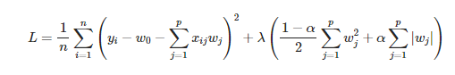

where 0 ≤ α ≤ 1.

Elastic net is same as lasso when α =1,

and ridge when α = 0. For other values of α, the penalty term interpolate between L1 and L2 norm of the coefficient.

```python
# instantiate
elasticnet = Regression(X,Y)

# fit ElasticNet
elasticnet_model , elasticnet_intercept, elasticnet_coef, elasticnet_y_pred = elasticnet.fit_predict(ElasticNet(alpha=0.5, l1_ratio=1e-10, random_state=0), MinMaxScaler())
elasticnet_model , elasticnet_intercept, elasticnet_coef, X.columns
```

```
(Pipeline(steps=[('scaler', MinMaxScaler()),
                 ('regressor',
                  ElasticNet(alpha=0.5, l1_ratio=1e-10, random_state=0))]),
 1324.2541981226652,
 array([ 4.32950289,  1.60294587,  1.61203531, 90.56689146,  8.14025624,
         5.47079532]),
 Index(['HL', 'LRET', 'PRET', 'EWMA_7', 'HL7', 'MOM7'], dtype='object'))
```

- Again ElasticNet does the same as Ridge, it shrinks the coefficients and reduces multi-collinearity but I cannot remove any for the future modeling.
- The lambda parameter will have to be adjusted and tuned in future steps to see if we can improve on this.

### Comparison of Models - Lasso, Ridge & ElasticNet

```python
# compare model coefficients
coef_df = pd.DataFrame({
    'Lasso': lasso_coef,
    'Ridge': ridge_coef,
    'ElasticNet': elasticnet_coef
}, index = feature_names)

coef_df
```

|  | Lasso | Ridge | ElasticNet |
| --- | --- | --- | --- |
| HL | 0.0000 | 7.4393 | 4.3295 |
| LRET | 35.4959 | 40.8272 | 1.6029 |
| PRET | 11.5121 | 31.4658 | 1.6120 |
| EWMA_7 | 936.2839 | 823.2540 | 90.5669 |
| HL7 | 0.0000 | 26.9460 | 8.1403 |
| MOM7 | 79.5327 | 72.1481 | 5.4708 |

```python
# compare evaluation metrics
eval_df = pd.DataFrame({
    'Lasso': lasso.eval_metrics(lasso_model, lasso_y_pred),
    'Ridge': ridge.eval_metrics(ridge_model, ridge_y_pred),
    'ElasticNet': elasticnet.eval_metrics(elasticnet_model, elasticnet_y_pred)
}, index = ['MSE', 'RMSE', 'R2_train', 'R2_test'])

eval_df = eval_df.round(decimals =4)
eval_df
```

|  | Lasso | Ridge | ElasticNet |
| --- | --- | --- | --- |
| MSE | 377.0329 | 3,853.5464 | 184,547.2700 |
| RMSE | 19.4173 | 62.0769 | 429.5897 |
| R2_train | 0.9949 | 0.9800 | 0.1835 |
| R2_test | 0.9555 | 0.5448 | -20.8014 |

I have created an evolution matrix to compare the properties across these 3 models.

## Wrapper Methods for subset selection

Evaluates on a specific machine learning algorithm to find optimal features

### SHAP Method

The SHAP method uses a game theoretic approach. It can be described as the average marginal contribution of a feature value across all possible coalitions. SHAP deconstructs a prediction into a sum of contributions from each of the model's input variables.

Variables are sorted by their mean absolute SHAP value in descending order with the most important variables at the top. Each dot corresponds to one price return in my dataset. The beeswarm plot shows how the different variable expressions of each price affect the prediction of the ML model towards a T+1 movement in the Gold price. Positive SHAP values indicate a change in the expected model prediction to an increase in the T+1 Gold price.

```python
X.columns
```

```
Index(['HL', 'LRET', 'PRET', 'EWMA_7', 'HL7', 'MOM7'], dtype='object')
```

```python
pipe = Pipeline([
    ('scaler', MinMaxScaler()),
    ('regressor', LinearRegression())
])
```

```python
# 10 instances for use as the background distribution
X10 = shap.utils.sample(X, 10, random_state=42)
pipe.fit(X, Y)
```

```
Pipeline(steps=[('scaler', MinMaxScaler()), ('regressor', LinearRegression())])
```

```python
# Compute the SHAP values for the linear model
explainer = shap.Explainer(pipe.predict, X10)
shap_values = explainer(X)
```

```
Exact explainer: 2510it [00:26, 84.92it/s]
```

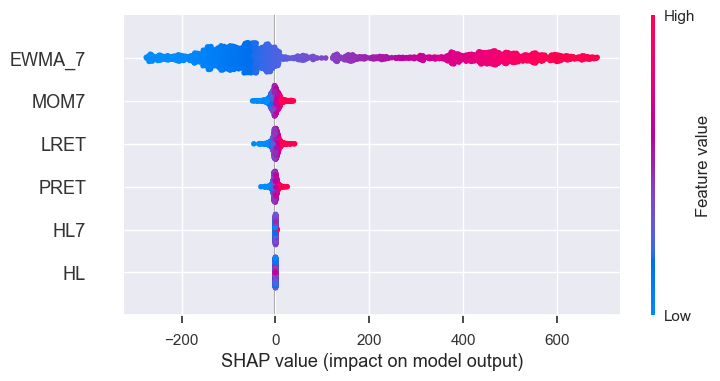

```python
shap.plots.beeswarm(shap_values, max_display=7)
```

#### Comment on SHAP

- 7 Day EWMA has clearly the strongest impact on the outcome of my model. The interpretation behind is that Gold prices might have a momentum effect on it. Here my SHAP diagram is showing me that GOLD is used as a flight to safety security. Where there are big and more significant moves on the positive side.
- The 7 day (MOM7) price change or momentum, 1 Day Log returns and Past Returns all have a similar distribution in the SHAP diagram. Small positive impact for high values, small negative impact for low values (generally).
- Furthermore, it is clear that the High-Low (HL & HL7) feature has little impact on my overall model. This kind of makes sense and adds to the evidence to drop it.

### Forward Selection

```python
X.columns
```

```
Index(['HL', 'LRET', 'PRET', 'EWMA_7', 'HL7', 'MOM7'], dtype='object')
```

```python
def forward_selection(data, target, significance_level=0.05):
    initial_features = data.columns.tolist()
    best_features = []
    while (len(initial_features)>0):
        remaining_features = list(set(initial_features)-set(best_features))
        new_pval = pd.Series(index=remaining_features)
        for new_column in remaining_features:
            model = sm.OLS(target, sm.add_constant(data[best_features+[new_column]])).fit()
            new_pval[new_column] = model.pvalues[new_column]
        min_p_value = new_pval.min()
        if(min_p_value<significance_level):
            best_features.append(new_pval.idxmin())
        else:
            break
    return best_features
```

```python
forward_selection(X,Y)
```

```
['EWMA_7', 'MOM7', 'LRET', 'PRET']
```

#### Forward Selection Comment

Here it is clear again that in my previous steps I have arrived at appropriate features in my model. The features obtained from the Forward Selection method are the same as those obtained from the wrapper methods employed above.

### Backward Selection

```python
def backward_elimination(data, target,significance_level = 0.05):
    features = data.columns.tolist()
    while(len(features)>0):
        features_with_constant = sm.add_constant(data[features])
        p_values = sm.OLS(target, features_with_constant).fit().pvalues[1:]
        max_p_value = p_values.max()
        if(max_p_value >= significance_level):
            excluded_feature = p_values.idxmax()
            features.remove(excluded_feature)
        else:
            break
    return features
```

```python
backward_elimination(X,Y)
```

```
['LRET', 'PRET', 'EWMA_7', 'MOM7']
```

Identical result as before, I think I have found a suitable set of features in order to proceed to the next model building step.

## Comment on overall feature selection engineering

Having constructed a dataframe of features derived from the daily price features, I have taken appropriate steps throughout the feature engineering phase to construct a dataset that should provide me promising results.

Firstly, I am confident that I have removed features that have properties of Multi-Collinearity that will affect the quality of my results. This was done via the correlation heat map.

Subsequently, I used embedded methods that included Lasso, Ridge and Elasticnet to shrink the size of my coefficients in order to reduce the number of features further. The results in these tests were supported by my results in SHAP & Forward/backward selection.

After all these methods, it is clear that I will proceed with the following 4 features in my model building phase. 'LRET': 1 Day Log Returns, 'PRET': Past Returns for T-1, 'EWMA_7': 7 Day Exponentially Weighted Moving Average, 'MOM7': 7 Day Momentum.

# Question 4 - Model Building & Evaluation

## Target or labeling my binary model for Long Only Strategy

Here I need to define my classes for the binomial classification. For a long only strategy, I need to check my class imbalance and either address this from the start using labeling or address this later when applying my Machine Learning technique. I will go through a few statistical methods to understand the distribution of my data a bit more.

### Kurtosis

Kurtosis measures where the weight of the distribution is. We are looking to see how the distribution of log returns are distributed.

```python
kurtosis(Xnew['LRET'].array)
```

```
4.209283611215173
```

Kurtosis of greater than 3, means that the distribution of log returns have fatter tails than a normal distribution. This will be an important point to remember when thinking about returns in the testing of the training set versus a buy and hold strategy.

This can be plotted below:

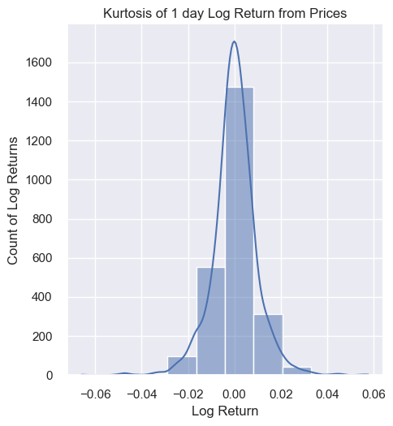

```python
import seaborn as sns
sns.displot(Xnew['LRET'].array, kde=True, bins=10).set(title='Kurtosis of 1 day Log Return from Prices',xlabel='Log Return',ylabel = 'Count of Log Returns')
```

```python
rets = X['LRET']
```

#### Draw downs

```python
def drawdown(returns):
    cumulative = (returns + 1).cumprod()
    running_max = np.maximum.accumulate(cumulative)
    return (cumulative - running_max) / running_max
```

The max drawdown differs from the drawdown by tracking the maximum drawdown of a 30-day rolling window of returns.

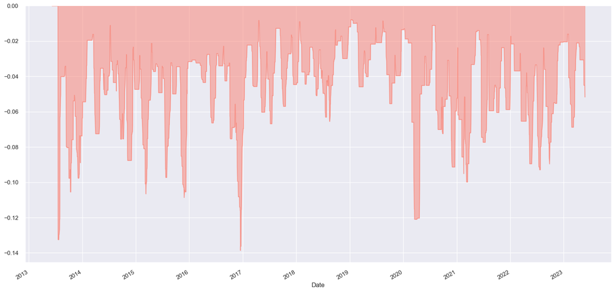

```python
def max_drawdown(returns):
    return np.min(drawdown(returns))

rets.rolling(30).apply(max_drawdown).plot(kind="area", color="salmon", alpha=0.5)
```

The 30day rolling drawdown should be more gentle yet it remains quite significant across the piece.

### Target Label

Checking my initial classes:

```python
Y_pre = np.where(df['ADJ CLOSE'].shift(-1)>df['ADJ CLOSE'],1,0)
Y_pre
# Value counts for class 1 and -1
pd.Series(Y_pre).value_counts()
```

```
1    1279
0    1230
dtype: int64
```

```python
Xnew.describe()
```

|  | LRET | PRET | EWMA_7 | MOM7 |
| --- | --- | --- | --- | --- |
| count | 2,509.0000 | 2,509.0000 | 2,509.0000 | 2,509.0000 |
| mean | 0.0001 | 0.0001 | 1,452.1121 | 1.5746 |
| std | 0.0097 | 0.0097 | 272.0194 | 36.9124 |
| min | -0.0660 | -0.0660 | 1,063.5635 | -197.2000 |
| 25% | -0.0045 | -0.0045 | 1,242.5942 | -20.0000 |
| 50% | 0.0002 | 0.0002 | 1,316.8345 | 1.5000 |
| 75% | 0.0051 | 0.0051 | 1,748.2353 | 23.0000 |
| max | 0.0578 | 0.0578 | 2,024.6879 | 166.6001 |

My classes are already largely balanced. When setting up my model, I will balance the classes in my target that can be seen below. Therefore, I do not have to worry about class imbalance.

\begin{equation} Y_t=\begin{cases} +1, & \text{if $ P_{t+1} > Med(P_t) $ }.\\ 0, & \text{$ Otherwise $}. \end{cases} \end{equation}

Where $ Med(P_t) $ is the median price of all prices in the series.

This should balance my two classes evenly.

```python
Y_bal = np.where(df['ADJ CLOSE'].shift(-1)>=np.quantile(df['ADJ CLOSE'], q=0.5), 1,0)
pd.Series(Y_bal).value_counts()
```

```
1    1255
0    1254
dtype: int64
```

## Training and testing Split

I am going to split my model in an 80/20 Training and Testing Split. Over 10 years of data and looking at daily price signals, this should be sufficient for my purposes.

```python
X_train, X_test, y_train, y_test = train_test_split(Xnew, Y_bal, test_size=0.2, shuffle=False)

# Output the train and test data size
print(f"Train and Test Size {len(X_train)}, {len(X_test)}")
```

```
Train and Test Size 2007, 502
```

## Model Selection - Support Vector Classifier

I am going to use sci-kit Learns SVC machine learning algorithm to begin with. This will provide me the classification setting using support vectors that I am looking for.

```python
# Scale and fit the model  - DEFAULT parameters used
bal_model = Pipeline([
    ("scaler", MinMaxScaler()),
    ("classifier", svm.SVC(probability=True))
])
bal_model.fit(X_train, y_train)
```

```
Pipeline(steps=[('scaler', MinMaxScaler()),
                ('classifier', SVC(probability=True))])
```

### Initial Prediction

```python
# Predicting the test dataset
y_pred = bal_model.predict(X_test)  ## Predicting the lables

# Predict Probabilities
y_proba = bal_model.predict_proba(X_test)
```

```python
acc_train = accuracy_score(y_train, bal_model.predict(X_train))
acc_test = accuracy_score(y_test, y_pred)

print(f'Train Accuracy: {acc_train:0.4}, Test Accuracy: {acc_test:0.4}')
```

```
Train Accuracy: 0.9671, Test Accuracy: 0.998
```

My initial model has shown very strong promise - I will now display the models confusion matrix.

### Confusion Matrix

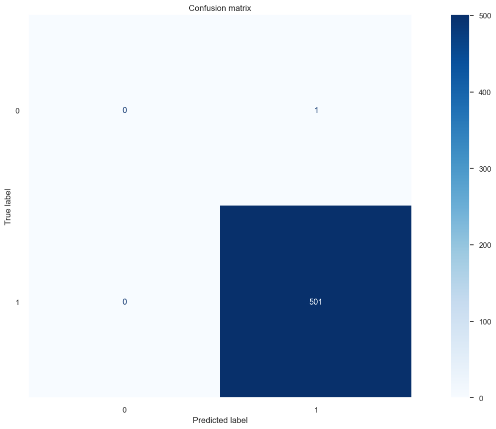

```python
disp = ConfusionMatrixDisplay.from_estimator(
        bal_model,
        X_test,
        y_test,
        display_labels=bal_model.classes_,
        cmap=plt.cm.Blues
    )
disp.ax_.set_title('Confusion matrix')
plt.grid(False)
plt.show()
```

My testing data has a clear weighting where the direction of stock price moves is in the positive direction.

I want to check that the data is not just categorising everything in the positive direction. In order to do this I will look at the confusion matrix for the training set.

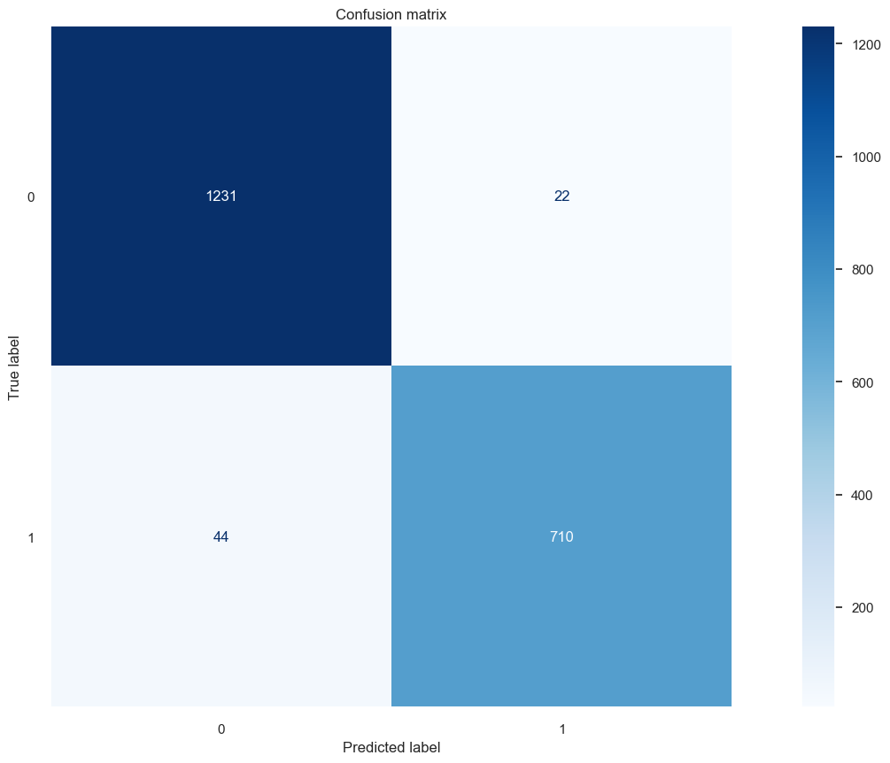

```python
disp = ConfusionMatrixDisplay.from_estimator(
        bal_model,
        X_train,
        y_train,
        display_labels=bal_model.classes_,
        cmap=plt.cm.Blues
    )
disp.ax_.set_title('Confusion matrix')
plt.grid(False)
plt.show()
```

This is a good example of the accuracy of this model, it is clearly accurate at predicting both the True Negatives and the true positives.

## Tuning Model

### Cross Validation of time series

This is one of the best cross-validation methods for time series data. It ensures the integrity of the data as it moves between training and testing.

```python
tscv = TimeSeriesSplit(n_splits=5, gap=1)
```

```python
bal_model.get_params()
```

```
{'memory': None,
 'steps': [('scaler', MinMaxScaler()), ('classifier', SVC(probability=True))],
 'verbose': False,
 'scaler': MinMaxScaler(),
 'classifier': SVC(probability=True),
 'scaler__clip': False,
 'scaler__copy': True,
 'scaler__feature_range': (0, 1),
 'classifier__C': 1.0,
 'classifier__break_ties': False,
 'classifier__cache_size': 200,
 'classifier__class_weight': None,
 'classifier__coef0': 0.0,
 'classifier__decision_function_shape': 'ovr',
 'classifier__degree': 3,
 'classifier__gamma': 'scale',
 'classifier__kernel': 'rbf',
 'classifier__max_iter': -1,
 'classifier__probability': True,
 'classifier__random_state': None,
 'classifier__shrinking': True,
 'classifier__tol': 0.001,
 'classifier__verbose': False}
```

```python
# Perform Gridsearch and fit
param_grid = {"classifier__C": np.arange(0.01,5,25),
             "classifier__kernel":['linear', 'rbf', 'poly','sigmoid'],
             "classifier__gamma":['scale', 'auto'],
             "classifier__decision_function_shape":['ovr', 'ovo']}

grid_search = GridSearchCV(bal_model, param_grid, n_jobs=-1, cv=tscv, verbose=1)
grid_search.fit(X_train, y_train)
```

```
Fitting 5 folds for each of 16 candidates, totalling 80 fits
```

```
GridSearchCV(cv=TimeSeriesSplit(gap=1, max_train_size=None, n_splits=5, test_size=None),
             estimator=Pipeline(steps=[('scaler', MinMaxScaler()),
                                       ('classifier', SVC(probability=True))]),
             n_jobs=-1,
             param_grid={'classifier__C': array([0.01]),
                         'classifier__decision_function_shape': ['ovr', 'ovo'],
                         'classifier__gamma': ['scale', 'auto'],
                         'classifier__kernel': ['linear', 'rbf', 'poly',
                                                'sigmoid']},
             verbose=1)
```

```python
# Print the best parameters and the corresponding score
print("Best Parameters: ", grid_search.best_params_)
print("Best Score: ", grid_search.best_score_)
```

```
Best Parameters:  {'classifier__C': 0.01, 'classifier__decision_function_shape': 'ovr', 'classifier__gamma': 'scale', 'classifier__kernel': 'poly'}
Best Score:  0.9730538922155688
```

## Tuned Model with best parameters

```python
tun_model = Pipeline([
    ("scaler", MinMaxScaler()),
    ("classifier", svm.SVC(probability=True, class_weight='balanced', C=0.01,
    decision_function_shape = 'ovr',gamma='scale',kernel='poly'))
])
tun_model.fit(X_train, y_train)
```

```
Pipeline(steps=[('scaler', MinMaxScaler()),
                ('classifier',
                 SVC(C=0.01, class_weight='balanced', kernel='poly',
                     probability=True))])
```

```python
# Predicting the test dataset
y_pred = tun_model.predict(X_test)  ## Predicting the lables

# Predict Probabilities
y_proba = tun_model.predict_proba(X_test)
```

```python
acc_train = accuracy_score(y_train, tun_model.predict(X_train))
acc_test = accuracy_score(y_test, y_pred)

print(f'Train Accuracy: {acc_train:0.4}, Test Accuracy: {acc_test:0.4}')
```

```
Train Accuracy: 0.9661, Test Accuracy: 0.998
```

The results haven't improved since the tuning of the model. The bar was set pretty high from the un-tuned model where the testing accuracy is 0.998 which is massive & is not exhibiting any properties of over-fitting. Overall, I am very happy with this result. I am going to display these results below using the Confusion matrix, ROC Curve and classification report.

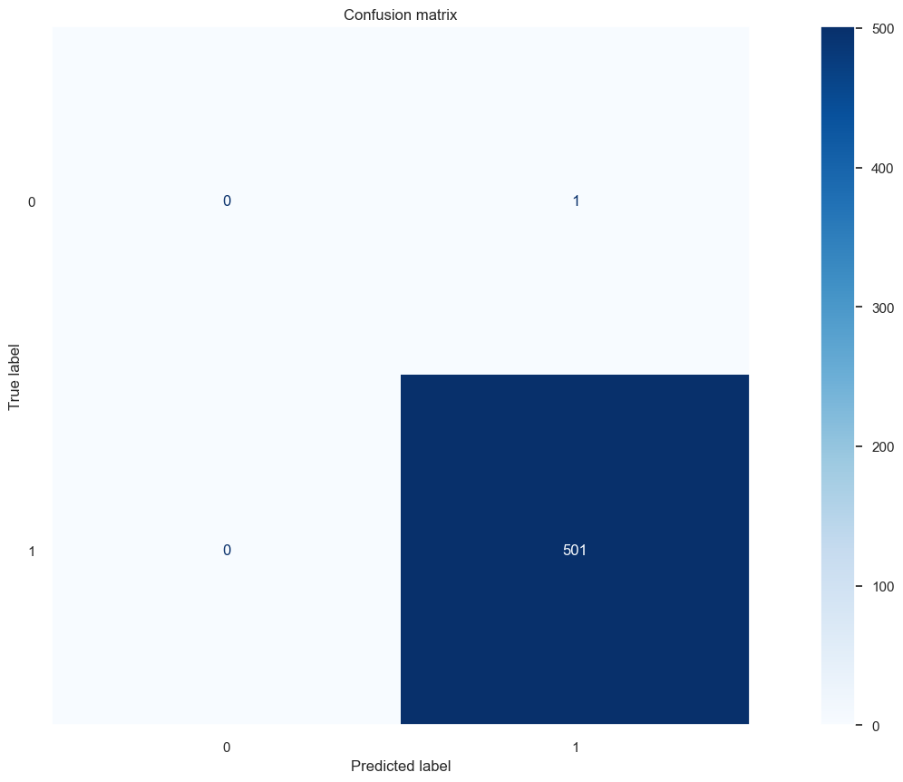

```python
disp = ConfusionMatrixDisplay.from_estimator(
        bal_model,
        X_test,
        y_test,
        display_labels=bal_model.classes_,
        cmap=plt.cm.Blues
    )
disp.ax_.set_title('Confusion matrix')
plt.grid(False)
plt.show()
```

Here there is no improvement in the confusion matrix given our already very high accuracy. This is something that will show in the future ROC curve as well.

### ROC Curve

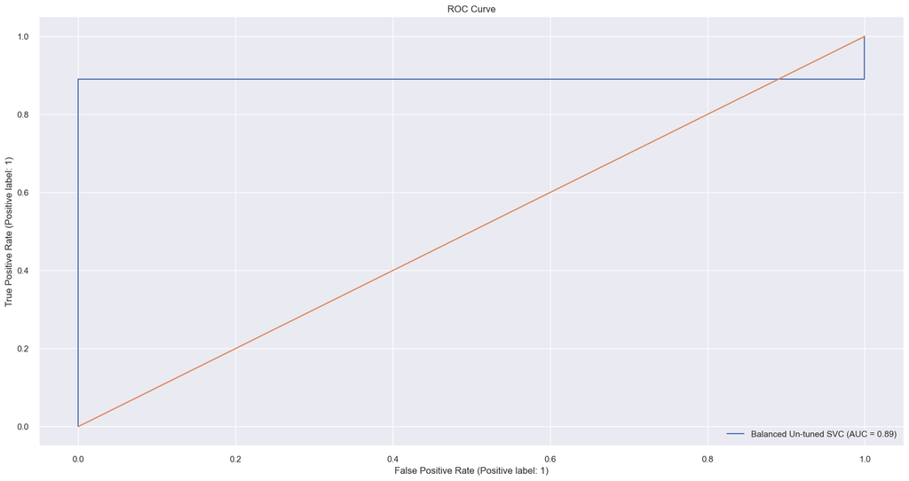

```python
# Display ROCCurve
disp_roc = RocCurveDisplay.from_estimator(
            bal_model,
            X_test,
            y_test,
            name='Balanced Un-tuned SVC')
disp_roc.ax_.set_title('ROC Curve')
plt.plot([0,1],[0,1])
plt.show()
```

The ROC curve here shows the obvious benefits of the TRUE positive classification.